# R Notes

# Table of Content

- Search for Documentation
- Install/Load Packages
- For Loop
- Loop Functions
- Debugging Tools
- Read/Write
- Exploratory Data Analysis
- Data Wrangling
- Plotting

## Search for Documentation

```r
?read.table
help.search('data input')
find('anova')
help(package=lubridate)

args('rnorm')
formals(rnorm)
str(rnorm)
```

[Return to Table of Content]

## Install/Load Packages

```r
a <- available.packages()
head(rownames(a), 3)
```

```
## [1] "A3"     "abbyyR" "abc"
```

```r
install.packages('swirl')
install.packages('lubridate')
install.packages('knitr')
```

Install packages from Bioconductor:

```r
source('http://bioconductor.org/biocLite.R')
biocLite(package.name)
```

Install more than one:

```r
biocLite(c('GenomicFeatures', 'AnnotationDbi'))
```

Load a library:

```r
library('swirl')
```

Unload a library:

```r
detach("package:RMySQL", unload=TRUE)
```

Check the version of a package:

```r
packageVersion('swirl')
```

```
## [1] '2.4.3'
```

Render Rmarkdown:

```r
library('knitr')
```

Run a R script:

```r
source('filename.R')
```

[Return to Table of Content]

## For Loop

Use `seq_along`:

```r
x <- c('a', 'b', 'c', 'd')
for(i in seq_along(x)) {
  print(x[i])
}
```

```
## [1] "a"
## [1] "b"
## [1] "c"
## [1] "d"
```

Use `seq_len`

```r
for(i in seq_len(length(x))) {
  print(x[i])
}
```

```
## [1] "a"
## [1] "b"
## [1] "c"
## [1] "d"
```

[Return to Table of Content]

## Loop Functions

- `apply`
- `lapply`
- `sapply`
- `vapply`
- `mapply`
- `tapply` (related function: `split`)

*Note*: `tapply` splits an atomic object, typically a vector; for a dataframe, use `split` combined with `lapply` or `sapply`. e.g.

```r
library(datasets)
s <- split(airquality, airquality$Month)
lapply(s, function(x) {colMeans(x[, c('Ozone', 'Solar.R', 'Wind')])})
```

```
## $`5`
##    Ozone  Solar.R     Wind
##       NA       NA 11.62258
##
## $`6`
##     Ozone   Solar.R      Wind
##        NA 190.16667  10.26667
##
## $`7`
##      Ozone    Solar.R       Wind
##         NA 216.483871   8.941935
##
## $`8`
##    Ozone  Solar.R     Wind
##       NA       NA 8.793548
##
## $`9`
##    Ozone  Solar.R     Wind
##       NA 167.4333  10.1800
```

Using `tapply` here returns an error:

```r
tapply(airquality, airquality$Month, function(x) {colMeans(x[, c('Ozone', 'Solar.R', 'Wind')])})
```

```
## Error in tapply(airquality, airquality$Month, function(x) {: arguments must have same length
```

This is because `length(dataframe)` return the number of columns in the dataframe (not the number of rows).

[Return to Table of Content]

## Debugging Tools

These are interactive tools that are meant to be used in the console: * `traceback`

```r
library(datasets)
tapply(airquality, airquality$Month, function(x) {colMeans(x[, c('Ozone', 'Solar.R', 'Wind')])})
```

```
## Error in tapply(airquality, airquality$Month, function(x) {: arguments must have same length
```

```r
traceback()
```

```
## No traceback available
```

- `debug`

```r
debug(tapply)
tapply(airquality, airquality$Month, function(x) {colMeans(x[, c('Ozone', 'Solar.R', 'Wind')])})
n  # for the next line
```

- `browser`
- `trace`
- `recover`

```r
options(error = recover)
```

[Return to Table of Content]

## Read/Write

- Read/Write R Objects
- Download Data
- Read/Write Excel Files
- Read XML
- Read HTML (Webpages)
- Read from APIs
- Read/Write JSON
- Read from MySQL
- Read from HDF5

### Further reading:

- `?connections`
- [This R Data Import Tutorial Is Everything You Need](https://www.r-bloggers.com/this-r-data-import-tutorial-is-everything-you-need/)

### Other database packages:

- `RPostgresql`
- `RODBC`
- `RMongo`

### Read images:

- `jpeg`
- `readbitmap`
- `png`
- `EBImage` (Bioconductor)

### Read GIS data:

- `rdgal`
- `rgeos`
- `raster`

### Read music data:

- `tuneR`
- `seewave`

### Read/Write R Objects

#### `dput` & `dget` — one R object:

```r
y <- data.frame(a = 1, b = 'a')
dput(y, file = 'y.R')
new.y <- dget('y.R')
```

#### `dump` & `source` — multiple R objects:

```r
x <- 'foo'
y <- data.frame(a = 1, b = 'a')
dump(c('x', 'y'), file = 'data.R')
rm(x, y)
source('data.R')
```

[Return to Table of Content]

### Download Data

```r
download.file('https://ailuropoda1864.github.io/portfolio/resume_Jingfei_Cai.pdf', destfile = 'resume.pdf')
```

[Return to Table of Content]

### Read/Write Excel Files

Read Excel files:

```r
library(xlsx)
data <- read.xlsx('filename.xlsx', sheetIndex=1, header=TRUE)
```

Write Excel files:

```r
write.xlsx()
```

[Return to Table of Content]

### Read XML

```r
library(XML)
fileUrl <- 'https://www.w3schools.com/xml/simple.xml'
download.file(fileUrl, destfile = 'example_files/simple.xml')
doc <- xmlTreeParse('example_files/simple.xml', useInternalNodes=TRUE)

rootNode <- xmlRoot(doc)
xmlName(rootNode)
```

```
## [1] "breakfast_menu"
```

#### Directly access parts of the XML document:

```r
rootNode[[1]]
```

```
## <food>
##   <name>Belgian Waffles</name>
##   <price>$5.95</price>
##   <description>Two of our famous Belgian Waffles with plenty of real maple syrup</description>
##   <calories>650</calories>
## </food>
```

```r
rootNode[[1]][[1]]
```

```
## <name>Belgian Waffles</name>
```

#### Programatically extract parts of the file:

```r
xmlSApply(rootNode, xmlValue)
```

```
##                                                                                                                     food
##                               "Belgian Waffles$5.95Two of our famous Belgian Waffles with plenty of real maple syrup650"
##                                                                                                                     food
##                    "Strawberry Belgian Waffles$7.95Light Belgian waffles covered with strawberries and whipped cream900"
##                                                                                                                     food
## "Berry-Berry Belgian Waffles$8.95Light Belgian waffles covered with an assortment of fresh berries and whipped cream900"
##                                                                                                                     food
##                                                "French Toast$4.50Thick slices made from our homemade sourdough bread600"
##                                                                                                                     food
##                         "Homestyle Breakfast$6.95Two eggs, bacon or sausage, toast, and our ever-popular hash browns950"
```

#### Extract elements using xpath:

```r
xpathSApply(rootNode, '//name', xmlValue)
```

```
## [1] "Belgian Waffles"             "Strawberry Belgian Waffles"
## [3] "Berry-Berry Belgian Waffles" "French Toast"
## [5] "Homestyle Breakfast"
```

```r
xpathSApply(rootNode, '//price', xmlValue)
```

```
## [1] "$5.95" "$7.95" "$8.95" "$4.50" "$6.95"
```

[Return to Table of Content]

### Read HTML (Webpages)

```r
con <- url('https://nationalzoo.si.edu/news/webcam/archive/2238', 'r')
html <- readLines(con)
close(con)

head(html)
```

```
## [1] "<!DOCTYPE html>"
## [2] "<html lang=\"en\" dir=\"ltr\""
## [3] "  xmlns:og=\"http://ogp.me/ns#\""
## [4] "  xmlns:article=\"http://ogp.me/ns/article#\""
## [5] "  xmlns:book=\"http://ogp.me/ns/book#\""
## [6] "  xmlns:profile=\"http://ogp.me/ns/profile#\""
```

Parse HTML:

```r
library(XML)
doc <- htmlTreeParse(html, useInternalNodes = TRUE)
links <- xpathSApply(doc,
                     '//div[@class="views-field views-field-title"]/span[@class="field-content"]/a',
                     xmlGetAttr,
                     name='href')
links
```

```
##  [1] "/events/easter-monday"
##  [2] "/support/adopt"
##  [3] "/animals/news/giant-pandas-winter"
##  [4] "/animals/news/bei-bei-update-november-2017"
##  [5] "/animals/news/tian-tian-gets-full-veterinary-checkup"
##  [6] "/news/giant-panda-mei-xiang-not-pregnant"
##  [7] "/animals/news/behavior-watch-for-mei-xiang-begins"
##  [8] "/animals/news/how-artificial-insemination-helps-boost-panda-populations"
##  [9] "/animals/news/mei-xiang-showing-more-behavioral-changes"
## [10] "/news/bei-bei-celebrates-his-second-birthday-smithsonians-national-zoo"
## [11] "/animals/news/how-panda-pregnancies-can-be-months-long-waiting-game"
## [12] "/animals/news/partial-panda-house-closure"
## [13] "/animals/news/search-three-ounce-bundle-panda"
## [14] "/animals/news/reading-hormones"
## [15] "/animals/news/giant-pandas-summertime"
## [16] "/news/smithsonians-national-zoo-and-conservation-biology-institute-scientists-artificially-inseminate"
## [17] "/animals/news/mei-xiang-showing-signs-estrus"
## [18] "/animals/news/how-bei-bei-has-started-his-summer"
## [19] "/animals/news/giant-panda-breeding-season-almost-here"
## [20] "/animals/news/giant-panda-cub-weaning-faq"
## [21] "/animals/news/bao-bao-settling-her-new-home"
## [22] "/animals/news/bei-bei-weaning"
## [23] "/animals/news/bao-bao-arrives-china"
## [24] "/news/giant-panda-bao-bao-arrives-safely-china-0"
## [25] "/animals/news/bao-bao-all-feels-video"
## [26] "/news/giant-panda-bao-bao-departs-smithsonians-national-zoo-for-china"
## [27] "/animals/news/keepers-favorite-memories-bao-bao"
```

Alternatively, use `httr` library:

```r
library(httr)
html2 <- GET('https://nationalzoo.si.edu/news/webcam/archive/2238')
content2 <- content(html2, as='text')

parsedHtml <- htmlParse(content2, asText=TRUE)
xpathSApply(parsedHtml,
            '//div[@class="views-field views-field-title"]/span[@class="field-content"]/a',
            xmlGetAttr,
            name='href')
```

```
##  [1] "/events/easter-monday"
##  [2] "/support/adopt"
##  [3] "/animals/news/giant-pandas-winter"
##  [4] "/animals/news/bei-bei-update-november-2017"
##  [5] "/animals/news/tian-tian-gets-full-veterinary-checkup"
##  [6] "/news/giant-panda-mei-xiang-not-pregnant"
##  [7] "/animals/news/behavior-watch-for-mei-xiang-begins"
##  [8] "/animals/news/how-artificial-insemination-helps-boost-panda-populations"
##  [9] "/animals/news/mei-xiang-showing-more-behavioral-changes"
## [10] "/news/bei-bei-celebrates-his-second-birthday-smithsonians-national-zoo"
## [11] "/animals/news/how-panda-pregnancies-can-be-months-long-waiting-game"
## [12] "/animals/news/partial-panda-house-closure"
## [13] "/animals/news/search-three-ounce-bundle-panda"
## [14] "/animals/news/reading-hormones"
## [15] "/animals/news/giant-pandas-summertime"
## [16] "/news/smithsonians-national-zoo-and-conservation-biology-institute-scientists-artificially-inseminate"
## [17] "/animals/news/mei-xiang-showing-signs-estrus"
## [18] "/animals/news/how-bei-bei-has-started-his-summer"
## [19] "/animals/news/giant-panda-breeding-season-almost-here"
## [20] "/animals/news/giant-panda-cub-weaning-faq"
## [21] "/animals/news/bao-bao-settling-her-new-home"
## [22] "/animals/news/bei-bei-weaning"
## [23] "/animals/news/bao-bao-arrives-china"
## [24] "/news/giant-panda-bao-bao-arrives-safely-china-0"
## [25] "/animals/news/bao-bao-all-feels-video"
## [26] "/news/giant-panda-bao-bao-departs-smithsonians-national-zoo-for-china"
## [27] "/animals/news/keepers-favorite-memories-bao-bao"
```

**Note:** `xmlParse` and `htmlParse` are equivalent to the `xmlTreeParse` and `htmlTreeParse` respectively, except they both use a default value for the `useInternalNodes` parameter of TRUE, i.e. they working with and return internal nodes/C-level nodes. These can then be searched using XPath expressions via `xpathApply` and `getNodeSet`.

`GET` in `httr` can be used to access website with passwords:

```r
pg2 = GET(url.string, authenticate('user', 'passwd'))
```

Use handles to preserve preserves settings and cookies across multiple requests (e.g. authentication):

```r
google <- handle('http://google.com')
pg1 <- GET(handle = google, path='/')
pg2 <- GET(handle = google, path='search')
```

[Return to Table of Content]

### Read from APIs

```r
library(httr)
myapp <- oauth_app('twitter', key='consumerKey', secret='consumerSecret')
sig <- sign_oauth1.0(myapp, token='token', token_secret='tokenSecret')
homeTL <- GET('https://api.twitter.com/1.1/statuses/home_timeline.json', sig)
json1 <- content(homeTL)

# use the jsonlite library to reformat the json object so that it's easier to read
json2 <- jsonlite::fromJSON(toJSON(json1))
```

[Return to Table of Content]

### Read/Write JSON

#### Read JSON:

```r
library(jsonlite)
jsonData <- fromJSON('https://api.github.com/users/Ailuropoda1864/repos')
names(jsonData)
```

```
##  [1] "id"                "name"              "full_name"
##  [4] "owner"             "private"           "html_url"
##  [7] "description"       "fork"              "url"
## [10] "forks_url"         "keys_url"          "collaborators_url"
## [13] "teams_url"         "hooks_url"         "issue_events_url"
## [16] "events_url"        "assignees_url"     "branches_url"
## [19] "tags_url"          "blobs_url"         "git_tags_url"
## [22] "git_refs_url"      "trees_url"         "statuses_url"
## [25] "languages_url"     "stargazers_url"    "contributors_url"
## [28] "subscribers_url"   "subscription_url"  "commits_url"
## [31] "git_commits_url"   "comments_url"      "issue_comment_url"
## [34] "contents_url"      "compare_url"       "merges_url"
## [37] "archive_url"       "downloads_url"     "issues_url"
## [40] "pulls_url"         "milestones_url"    "notifications_url"
## [43] "labels_url"        "releases_url"      "deployments_url"
## [46] "created_at"        "updated_at"        "pushed_at"
## [49] "git_url"           "ssh_url"           "clone_url"
## [52] "svn_url"           "homepage"          "size"
## [55] "stargazers_count"  "watchers_count"    "language"
## [58] "has_issues"        "has_projects"      "has_downloads"
## [61] "has_wiki"          "has_pages"         "forks_count"
## [64] "mirror_url"        "archived"          "open_issues_count"
## [67] "license"           "forks"             "open_issues"
## [70] "watchers"          "default_branch"
```

#### Write data frames to JSON (result hidden):

```r
library(datasets)
myjson <- toJSON(iris, pretty=TRUE)  # pretty print
cat(myjson)
```

```r
iris2 <- fromJSON(myjson)
head(iris2)
```

|  | Sepal.Length | Sepal.Width | Petal.Length | Petal.Width | Species |
| --- | --- | --- | --- | --- | --- |
| 1 | 5.1 | 3.5 | 1.4 | 0.2 | setosa |
| 2 | 4.9 | 3.0 | 1.4 | 0.2 | setosa |
| 3 | 4.7 | 3.2 | 1.3 | 0.2 | setosa |
| 4 | 4.6 | 3.1 | 1.5 | 0.2 | setosa |
| 5 | 5.0 | 3.6 | 1.4 | 0.2 | setosa |
| 6 | 5.4 | 3.9 | 1.7 | 0.4 | setosa |

[Return to Table of Content]

### Read from MySQL

Functions covered:

- `dbConnect`
- `dbDisconnect`
- `dbListTables`
- `dbReadTable`
- `dbListFields`
- `dbGetQuery`
- `dbSendQuery`
- `dbFetch`
- `dbClearResult`

Further reading:

- [MySQL and R](https://www.r-bloggers.com/mysql-and-r/)

Connect to and query a MySQL server:

```r
library(RMySQL)
ucscDb <- dbConnect(MySQL(), user='genome', host='genome-mysql.soe.ucsc.edu')
result <- dbGetQuery(ucscDb, 'show databases;')
dbDisconnect(ucscDb)
```

```
## [1] TRUE
```

```r
head(result)
```

|  | Database |
| --- | --- |
| 1 | information_schema |
| 2 | ailMel1 |
| 3 | allMis1 |
| 4 | anoCar1 |
| 5 | anoCar2 |
| 6 | anoGam1 |

Connect to a specific database:

```r
hg19 <- dbConnect(MySQL(), user='genome', host='genome-mysql.soe.ucsc.edu',
                  db='hg19')
```

List all tables:

```r
allTables <- dbListTables(hg19)
length(allTables)
```

```
## [1] 11107
```

```r
allTables[1:5]
```

```
## [1] "HInv"         "HInvGeneMrna" "acembly"      "acemblyClass"
## [5] "acemblyPep"
```

Get dimensions of a specific table:

```r
dbListFields(hg19, 'affyU133Plus2')
```

```
##  [1] "bin"         "matches"     "misMatches"  "repMatches"  "nCount"
##  [6] "qNumInsert"  "qBaseInsert" "tNumInsert"  "tBaseInsert" "strand"
## [11] "qName"       "qSize"       "qStart"      "qEnd"        "tName"
## [16] "tSize"       "tStart"      "tEnd"        "blockCount"  "blockSizes"
## [21] "qStarts"     "tStarts"
```

Make a query:

```r
dbGetQuery(hg19, 'SELECT count(*) FROM affyU133Plus2;')
```

| count(*) |
| --- |
| 58463 |

Read from a specific table:

```r
affyData <- dbReadTable(hg19, 'affyU133Plus2')
head(affyData)
```

|  | bin | matches | misMatches | repMatches | nCount | qNumInsert | qBaseInsert | tNumInsert | tBaseInsert | strand | qName | qSize | qStart | qEnd | tName | tSize | tStart | tEnd | blockCount | blockSizes | qStarts | tStarts |
| --- | --- | --- | --- | --- | --- | --- | --- | --- | --- | --- | --- | --- | --- | --- | --- | --- | --- | --- | --- | --- | --- | --- |
| 1 | 585 | 530 | 4 | 0 | 23 | 3 | 41 | 3 | 898 | - | 225995_x_at | 637 | 5 | 603 | chr1 | 249250621 | 14361 | 15816 | 5 | 93,144,229,70,21, | 34,132,278,541,611, | 14361,14454,14599,14968,15795, |
| 2 | 585 | 3355 | 17 | 0 | 109 | 9 | 67 | 9 | 11621 | - | 225035_x_at | 3635 | 0 | 3548 | chr1 | 249250621 | 14381 | 29483 | 17 | 73,375,71,165,303,360,198,661,201,1,260,250,74,73,98,155,163, | 87,165,540,647,818,1123,1484,1682,2343,2545,2546,2808,3058,3133,3206,3317,3472, | 14381,14454,14969,15075,15240,15543,15903,16104,16853,17054,17232,17492,17914,17988,18267,24736,29320, |
| 3 | 585 | 4156 | 14 | 0 | 83 | 16 | 18 | 2 | 93 | - | 226340_x_at | 4318 | 3 | 4274 | chr1 | 249250621 | 14399 | 18745 | 18 | 690,10,32,33,376,4,5,15,5,11,7,41,277,859,141,51,443,1253, | 44,735,746,779,813,1190,1195,1201,1217,1223,1235,1243,1285,1564,2423,2565,2617,3062, | 14399,15089,15099,15131,15164,15540,15544,15549,15564,15569,15580,15587,15628,15906,16857,16998,17049,17492, |
| 4 | 585 | 4667 | 9 | 0 | 68 | 21 | 42 | 3 | 5743 | - | 1557034_s_at | 4834 | 48 | 4834 | chr1 | 249250621 | 14406 | 24893 | 23 | 99,352,286,24,49,14,6,5,8,149,14,44,98,12,10,355,837,59,8,1500,133,624,58, | 0,99,452,739,764,814,829,836,842,851,1001,1016,1061,1160,1173,1184,1540,2381,2441,2450,3951,4103,4728, | 14406,20227,20579,20865,20889,20938,20952,20958,20963,20971,21120,21134,21178,21276,21288,21298,21653,22492,22551,22559,24059,24211,24835, |
| 5 | 585 | 5180 | 14 | 0 | 167 | 10 | 38 | 1 | 29 | - | 231811_at | 5399 | 0 | 5399 | chr1 | 249250621 | 19688 | 25078 | 11 | 131,26,1300,6,4,11,4,7,358,3359,155, | 0,132,159,1460,1467,1472,1484,1489,1497,1856,5244, | 19688,19819,19845,21145,21151,21155,21166,21170,21177,21535,24923, |
| 6 | 585 | 468 | 5 | 0 | 14 | 0 | 0 | 0 | 0 | - | 236841_at | 487 | 0 | 487 | chr1 | 249250621 | 27542 | 28029 | 1 | 487, | 0, | 27542, |

Select a specific subset:

```r
query.string <-
'SELECT * from affyU133Plus2
WHERE misMatches BETWEEN 1 AND 3'

affyMis <- dbGetQuery(hg19, query.string, n=10)
dim(affyMis)
```

```
## [1] 10 22
```

**Note:** `dbGetQuery()` is equivalent to `dbSendQuery()`, then `dbFetch()`, ensuring that the result is always free-d by `dbClearResult()`.

```r
query.string <-
'SELECT * from affyU133Plus2
WHERE misMatches BETWEEN 1 AND 3'

query <- dbSendQuery(hg19, query.string)
affyMis <- fetch(query, n=10)
dbClearResult(query)

dim(affyMis)
```

Close connection when done:

```r
dbDisconnect(hg19)
```

```
## [1] TRUE
```

[Return to Table of Content]

### Read from HDF5

Install R HDF 5 package:

```r
source('http://bioconductor.org/biocLite.R')
biocLite('rhdf5')
```

Create a HDF5 file:

```r
library(rhdf5)
h5.file <- 'example_files/example.h5'
created <- h5createFile(h5.file)
```

```
## file '/home/fay/code/r_coursera/example_files/example.h5' already exists.
```

```r
created
```

```
## [1] FALSE
```

Create groups:

```r
created <- h5createGroup(h5.file, 'foo')
```

```
## Can not create group. Object with name 'foo' already exists.
```

```r
created <- h5createGroup(h5.file, 'baa')
```

```
## Can not create group. Object with name 'baa' already exists.
```

```r
created <- h5createGroup(h5.file, 'foo/foobaa')
```

```
## Can not create group. Object with name 'foo/foobaa' already exists.
```

```r
h5ls(h5.file)
```

|  | group | name | otype | dclass | dim |
| --- | --- | --- | --- | --- | --- |
| 0 | / | baa | H5I_GROUP |  |  |
| 1 | / | foo | H5I_GROUP |  |  |
| 2 | /foo | A | H5I_DATASET | INTEGER | 5 x 2 |
| 3 | /foo | foobaa | H5I_GROUP |  |  |
| 4 | /foo/foobaa | B | H5I_DATASET | FLOAT | 5 x 2 x 2 |

Write to groups:

```r
A <- matrix(1:10, nrow = 5)
h5write(A, h5.file, 'foo/A')

B <- array(seq(0.1, 2.0, by=0.1), dim=c(5,2,2))
attr(B, 'scale') <- 'liter'
h5write(B, h5.file, 'foo/foobaa/B')

h5ls(h5.file)
```

|  | group | name | otype | dclass | dim |
| --- | --- | --- | --- | --- | --- |
| 0 | / | baa | H5I_GROUP |  |  |
| 1 | / | foo | H5I_GROUP |  |  |
| 2 | /foo | A | H5I_DATASET | INTEGER | 5 x 2 |
| 3 | /foo | foobaa | H5I_GROUP |  |  |
| 4 | /foo/foobaa | B | H5I_DATASET | FLOAT | 5 x 2 x 2 |

Read from a HDF5 file:

```r
readA <- h5read(h5.file, 'foo/A')
readB <- h5read(h5.file, 'foo/foobaa/B')

readA
```

```
##      [,1] [,2]
## [1,]    1    6
## [2,]    2    7
## [3,]    3    8
## [4,]    4    9
## [5,]    5   10
```

Read/write in chunks:

```r
h5write(c(12, 13, 14), h5.file, 'foo/A',
        index=list(1:3, 1))  # write to the first 3 rows in the first column
h5read(h5.file, 'foo/A')
```

```
##      [,1] [,2]
## [1,]   12    6
## [2,]   13    7
## [3,]   14    8
## [4,]    4    9
## [5,]    5   10
```

```r
h5read(h5.file, 'foo/A', index=list(1:3, 2))
```

```
##      [,1]
## [1,]    6
## [2,]    7
## [3,]    8
```

[Return to Table of Content]

## Exploratory Data Analysis

#### What the actual data looks like

```r
data("UCBAdmissions")
df <- as.data.frame(UCBAdmissions)

head(df)
```

|  | Admit | Gender | Dept | Freq |
| --- | --- | --- | --- | --- |
| 1 | Admitted | Male | A | 512 |
| 2 | Rejected | Male | A | 313 |
| 3 | Admitted | Female | A | 89 |
| 4 | Rejected | Female | A | 19 |
| 5 | Admitted | Male | B | 353 |
| 6 | Rejected | Male | B | 207 |

```r
tail(df, 3)
```

|  | Admit | Gender | Dept | Freq |
| --- | --- | --- | --- | --- |
| 22 | Rejected | Male | F | 351 |
| 23 | Admitted | Female | F | 24 |
| 24 | Rejected | Female | F | 317 |

#### Numbers of rows/columns, names of rows/columns, the class of each column, any missing values, any duplicates

```r
str(df)  # info() in Python
```

```
## 'data.frame':    24 obs. of  4 variables:
##  $ Admit : Factor w/ 2 levels "Admitted","Rejected": 1 2 1 2 1 2 1 2 1 2 ...
##  $ Gender: Factor w/ 2 levels "Male","Female": 1 1 2 2 1 1 2 2 1 1 ...
##  $ Dept  : Factor w/ 6 levels "A","B","C","D",..: 1 1 1 1 2 2 2 2 3 3 ...
##  $ Freq  : num  512 313 89 19 353 207 17 8 120 205 ...
```

```r
rownames(df)  # df.index in Python
```

```
##  [1] "1"  "2"  "3"  "4"  "5"  "6"  "7"  "8"  "9"  "10" "11" "12" "13" "14"
## [15] "15" "16" "17" "18" "19" "20" "21" "22" "23" "24"
```

```r
names(df)  # df.columns in Python
```

```
## [1] "Admit"  "Gender" "Dept"   "Freq"
```

```r
# missing values
sum(is.na(df$Admit))
```

```
## [1] 0
```

```r
colSums(is.na(df))
```

```
##  Admit Gender   Dept   Freq
##      0      0      0      0
```

```r
# duplicates
sum(duplicated(df))
```

```
## [1] 0
```

#### Distributions

- Quantitative variables: quantiles
- Qualatative variables: number of levels; count for each level

```r
summary(df)  # describe() in Python
```

```
##       Admit       Gender   Dept       Freq
##  Admitted:12   Male  :12   A:4   Min.   :  8.0
##  Rejected:12   Female:12   B:4   1st Qu.: 80.0
##                            C:4   Median :170.0
##                            D:4   Mean   :188.6
##                            E:4   3rd Qu.:302.5
##                            F:4   Max.   :512.0
```

```r
quantile(df$Freq, na.rm=TRUE, probs=c(0, 0.25, 0.5, 0.75, 1))
```

```
##    0%   25%   50%   75%  100%
##   8.0  80.0 170.0 302.5 512.0
```

```r
table(df$Admit, useNA='ifany')  # value_counts in Python
```

```
##
## Admitted Rejected
##       12       12
```

```r
table(df$Gender, df$Dept)
```

```
##
##          A B C D E F
##   Male   2 2 2 2 2 2
##   Female 2 2 2 2 2 2
```

#### Crosstab

```r
xtabs(Freq ~ Gender + Admit, data=df)
```

```
##         Admit
## Gender   Admitted Rejected
##   Male       1198     1493
##   Female      557     1278
```

[Return to Table of Content]

## Data Wrangling

- Handle Missing Values
- Factor
- Text
- RegEx
- Datetime
- `data.table`
- `plyr`
- `dplyr`
- `tidyr`
- Reshape Data
- Merge Data

### Handle Missing Values

```r
x <- c(1, 2, NA, 4, NA, 5)
bad <- is.na(x)
x[!bad]
```

```
## [1] 1 2 4 5
```

```r
y <- c('a', 'b', 'd', NA, NA, 'f')
good <- complete.cases(x, y)
x[good]
```

```
## [1] 1 2 5
```

`complete.cases` can also be used with dataframes: `complete.cases(dataframe_object)`

When subsetting a vector/data frame containing `NA` using conditional, use `which`:

```r
x[which(x>2)]
```

```
## [1] 4 5
```

```r
# compare with
x[x>2]
```

```
## [1] NA  4 NA  5
```

[Return to Table of Content]

### Factor

```r
x <- factor(c("yes", "yes", "no", "yes", "no"), levels = c("yes", "no"))
x
```

```
## [1] yes yes no  yes no
## Levels: yes no
```

```r
unclass(x)
```

```
## [1] 1 1 2 1 2
## attr(,"levels")
## [1] "yes" "no"
```

```r
relevel(x, ref='no')
```

```
## [1] yes yes no  yes no
## Levels: no yes
```

#### Generate factor levels

```r
f <- gl(2, 5)
f
```

```
##  [1] 1 1 1 1 1 2 2 2 2 2
## Levels: 1 2
```

#### Compute factor interactions

```r
x <- rnorm(10)
f1 <- gl(5, 2)
f2 <- gl(2, 5)
interaction(f1, f2)
```

```
##  [1] 1.1 1.1 2.1 2.1 3.1 3.2 4.2 4.2 5.2 5.2
## Levels: 1.1 2.1 3.1 4.1 5.1 1.2 2.2 3.2 4.2 5.2
```

#### Split

When more than one factors are put in a list, `split` will call `interaction` automatically:

```r
split(x, list(f1, f2))
```

```
## $`1.1`
## [1] 0.2223073 0.5367671
##
## $`2.1`
## [1] -0.2930562 -0.8064674
##
## $`3.1`
## [1] -0.1191927
##
## $`4.1`
## numeric(0)
##
## $`5.1`
## numeric(0)
##
## $`1.2`
## numeric(0)
##
## $`2.2`
## numeric(0)
##
## $`3.2`
## [1] 0.9133684
##
## $`4.2`
## [1] -0.2993354  0.4102467
##
## $`5.2`
## [1] 0.05786659 0.48214661
```

Drop empty levels:

```r
split(x, list(f1, f2), drop = TRUE)
```

```
## $`1.1`
## [1] 0.2223073 0.5367671
##
## $`2.1`
## [1] -0.2930562 -0.8064674
##
## $`3.1`
## [1] -0.1191927
##
## $`3.2`
## [1] 0.9133684
##
## $`4.2`
## [1] -0.2993354  0.4102467
##
## $`5.2`
## [1] 0.05786659 0.48214661
```

#### Create binary variables:

```r
ifelse(test, yes, no)
```

#### Create categorical variables

```r
cut(x, breaks)

# Alternatively
library(Hmisc)
cut2(x, g=4)
```

### Text

- `tolower` / `toupper`
- `strsplit`
- `sub` / `gsub`  
  can be RegEx
- `grep` (return indices or values) / `grepl` (return T/F)  
  can be RegEx
- `nchar`
- `substr`
- `paste` / `paste0`
- `stringr::str_trim`

[Return to Table of Content]

### RegEx

metacharacters:

- `^`  
  beginning
- `$`  
  end
- `.`  
  any character
- `|`  
  alternative patterns

escape:  
`\\`

[Return to Table of Content]

### Datetime

```r
library(lubridate)
today()
t1 <- now(tzone = "America/New_York")

update(now(), hours=14, minutes=3)
now() + hours(1) + minutes(2)

with_tz(now(), tzone='Asia/Hong_Kong')

time.between <- interval(t1, now())
as.period(time.between)
```

List of valid time zones for use with `lubridate`:  
http://en.wikipedia.org/wiki/List_of_tz_database_time_zones

[Return to Table of Content]

### `data.table`

```r
library(data.table)
```

```r
DT <- data.table(x=rnorm(9), y=rep(c('a', 'b', 'c'), each=3), z=rnorm(9))
head(DT, 3)
```

| x | y | z |
| --- | --- | --- |
| 0.428933 | a | 0.2183582 |
| 1.336505 | a | -0.6282804 |
| 0.104329 | a | 1.6962727 |

See all the data tables in memory:

```r
tables()
```

```
##      NAME NROW NCOL MB COLS  KEY
## [1,] DT      9    3  1 x,y,z
## Total: 1MB
```

Subset rows:

```r
DT[2,]
```

| x | y | z |
| --- | --- | --- |
| 1.336505 | a | -0.6282804 |

```r
DT[DT$y=='a',]
```

| x | y | z |
| --- | --- | --- |
| 0.428933 | a | 0.2183582 |
| 1.336505 | a | -0.6282804 |
| 0.104329 | a | 1.6962727 |

```r
DT[c(2,3)]
```

| x | y | z |
| --- | --- | --- |
| 1.336505 | a | -0.6282804 |
| 0.104329 | a | 1.6962727 |

Columns expressions:

```r
DT[, c(2,3)]
```

| y | z |
| --- | --- |
| a | 0.2183582 |
| a | -0.6282804 |
| a | 1.6962727 |
| b | 1.3952111 |
| b | -0.8203156 |
| b | 2.0541509 |
| c | -0.2911486 |
| c | -0.1432987 |
| c | -1.2009333 |

```r
DT[, list(mean(x), sum(z))]
```

| V1 | V2 |
| --- | --- |
| 0.3115972 | 2.280016 |

```r
DT[, table(y)]
```

```
## y
## a b c
## 3 3 3
```

```r
# add new columns
DT[, w:= z^2]

# multiple operations
DT[, m:= {tmp <- (x+z); log2(tmp+5)}]

# plyr-like operations
DT[, a:= x>0]
DT[, b:= mean(x+w), by=a]

# special variables
# .N is like count
DT[, .N, by=a]
```

| a | N |
| --- | --- |
| TRUE | 6 |
| FALSE | 3 |

Keys

```r
DT <- data.table(x=rep(c('a', 'b', 'c'), each=100), y=rnorm(300))
setkey(DT, x)
DT['a']
```

| x | y |
| --- | --- |
| a | 0.684785987 |
| a | 0.923155739 |
| a | -0.419485020 |
| a | 0.189978273 |
| a | 1.789241109 |
| a | -0.571535771 |
| a | 1.379628436 |
| a | 0.613690150 |
| a | 0.929993858 |
| a | -1.891105108 |

[output cut: 90 more lines]

Use keys to facilitate joins:

```r
DT1 <- data.table(x=c('a', 'a', 'b', 'dt1'), y=1:4)
DT2 <- data.table(x=c('a', 'b', 'dt2'), y=5:7)
setkey(DT1, x)
setkey(DT2, x)
merge(DT1, DT2)
```

| x | y.x | y.y |
| --- | --- | --- |
| a | 1 | 5 |
| a | 2 | 5 |
| b | 3 | 6 |

Read in file:

```r
fread(filename)
```

[Return to Table of Content]

### `plyr`

```r
library(plyr)
```

#### Order a dataframe by certain variables

```r
arrange(dataframe, var1)
# use base R:
dataframe[order(dataframe$var1), ]

# in descending order:
arrange(dataframe, desc(var1))
```

#### Copy a data frame and add new variables

```r
df2 <- mutate(df1, newCol=cut2(oldCol, g=4))
```

#### Split-apply-combine

```r
str(InsectSprays, 3)
```

```
## 'data.frame':    72 obs. of  2 variables:
##  $ count: num  10 7 20 14 14 12 10 23 17 20 ...
##  $ spray: Factor w/ 6 levels "A","B","C","D",..: 1 1 1 1 1 1 1 1 1 1 ...
```

```r
ddply(InsectSprays, .(spray), summarize, sum=sum(count))
```

| spray | sum |
| --- | --- |
| A | 174 |
| B | 184 |
| C | 25 |
| D | 59 |
| E | 42 |
| F | 200 |

Or, maintain the dimension so that a new variable can be created:

```r
spraySums <- ddply(InsectSprays, .(spray), summarize, sum=ave(count, FUN=sum))
dim(spraySums)
```

```
## [1] 72  2
```

```r
head(spraySums)
```

|  | spray | sum |
| --- | --- | --- |
| 1 | A | 174 |
| 2 | A | 174 |
| 3 | A | 174 |
| 4 | A | 174 |
| 5 | A | 174 |
| 6 | A | 174 |

#### Merge data

Compared with `merge` in base R, it is faster, but less full featured (defaults to left join)

```r
join(x, y, by = NULL, type = "left", match = "all")
```

Merge multiple data frames (which is more difficult with `merge`)

```r
df1 <- data.frame(id=sample(1:10), x=rnorm(10))
df2 <- data.frame(id=sample(1:10), y=rnorm(10))
df3 <- data.frame(id=sample(1:10), z=rnorm(10))
dfList = list(df1, df2, df3)
join_all(dfList)
```

| id | x | y | z |
| --- | --- | --- | --- |
| 4 | 1.7381401 | -0.05354515 | 1.54242160 |
| 8 | -1.2184225 | -0.13304963 | -0.32233916 |
| 1 | -1.3513646 | 1.32713747 | 0.88916734 |
| 2 | -0.4052006 | -0.16335252 | -0.04543174 |
| 7 | -2.6641421 | 1.48512116 | -0.13331799 |
| 5 | -1.4801648 | -0.37293928 | -1.16282906 |
| 10 | -0.1533664 | -0.85260283 | -0.34242135 |
| 3 | 0.6449722 | 0.27461468 | 0.80608250 |
| 6 | 1.3748370 | 1.48433079 | -0.57160726 |
| 9 | -0.1958607 | 0.77362619 | -0.94538206 |

[Return to Table of Content]

### `dplyr`

Convert a data frame to a “data frame tbl” object (for easier viewing):

```r
tbl_df(dataframe)
```

- `select` subsetting columns
- `filter` subsetting rows
- `arrange`
- `rename`  
  `rename(df, newName = oldName)`
- `mutate`
- `group_by`
- `summarize`
  - `n()`  
    total number of rows
  - `n_distinct(var)`  
    total number of unique rows
- `%>%`

[Return to Table of Content]

### `tidyr`

#### When column headers are values, not variable names

`gather`

#### When multiple variables are stored in one column

`separate`  
default to split on non-alphanumeric values (the `sep` argument)

#### When variables are stored in both rows and columns

`spread`

#### When multiple observational units are stored in the same table

`select` followed by `unique`

#### When a single observational unit is stored in multiple tables

`bind_rows`

[Return to Table of Content]

### Reshape Data

```r
library(reshape2)
```

#### Melt data frames

```r
melt(df, id, measure.vars)
```

#### Cast data frames

```r
dcast(data, formula, fun.aggregate)
```

See also: `acast`

[Return to Table of Content]

### Merge Data

`merge`  
`intersect`

[Return to Table of Content]

## Plotting

- Base
- lattice
- ggplot2
- Graphics Devices

### Base

Use `example(points)` to see examples (press `Esc` to exit).

#### Base graphics parameters

Use `?par` to see the complete list. Also: `names(par())`

To see the default values for global graphics paremeters:

```r
par('lty')
```

```
## [1] "solid"
```

- `pch`  
  The plottin symbol (default is open circle).
- `lty`  
  The line type. Line types can either be specified as an integer (0=blank, 1=solid (default), 2=dashed, 3=dotted, 4=dotdash, 5=longdash, 6=twodash) or as one of the character strings “blank”, “solid”, “dashed”, “dotted”, “dotdash”, “longdash”, or “twodash”, where “blank” uses ‘invisible lines’ (i.e., does not draw them).
- `col`  
  The plotting color. The `colors()` function provides a vector of colors by name.
- `las`  
  The orientation of the axis labels on the plot.
- `mfrow`  
  Number of plots per row, column (plots are filled row-wise).
- `mfcol`  
  Number of plots per row, column (plots are filled column-wise).

The par() function is used to specify global graphics parameters that affect all plots in an R session. (Use `dev.off` or `plot.new` to reset to the defaults.)

#### Scatterplot

```r
library('datasets')

head(cars)
```

|  | speed | dist |
| --- | --- | --- |
| 1 | 4 | 2 |
| 2 | 4 | 10 |
| 3 | 7 | 4 |
| 4 | 7 | 22 |
| 5 | 8 | 16 |
| 6 | 9 | 10 |

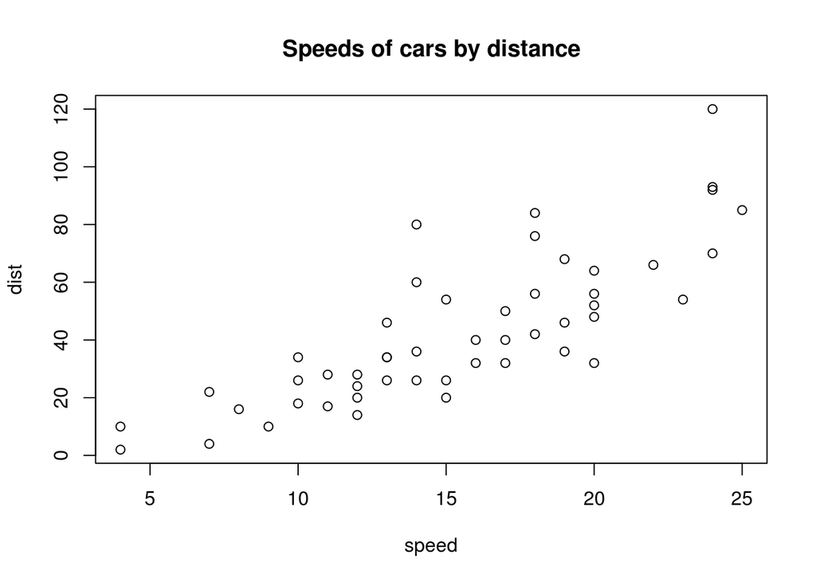

```r
plot(cars, main='Speeds of cars by distance')
```

```r
head(Puromycin)
```

|  | conc | rate | state |
| --- | --- | --- | --- |
| 1 | 0.02 | 76 | treated |
| 2 | 0.02 | 47 | treated |
| 3 | 0.06 | 97 | treated |
| 4 | 0.06 | 107 | treated |
| 5 | 0.11 | 123 | treated |
| 6 | 0.11 | 139 | treated |

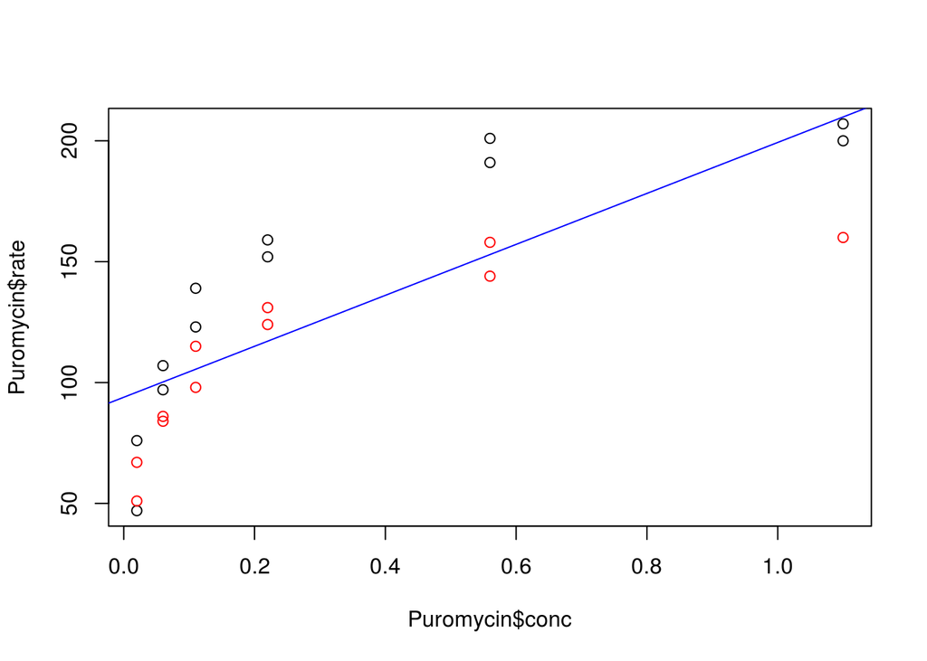

```r
plot(Puromycin$conc, Puromycin$rate, col=Puromycin$state)
# add regression line
model <- lm(rate ~ conc, Puromycin)
abline(model, col='blue')
```

```r
head(airquality)
```

|  | Ozone | Solar.R | Wind | Temp | Month | Day |
| --- | --- | --- | --- | --- | --- | --- |
| 1 | 41 | 190 | 7.4 | 67 | 5 | 1 |
| 2 | 36 | 118 | 8.0 | 72 | 5 | 2 |
| 3 | 12 | 149 | 12.6 | 74 | 5 | 3 |
| 4 | 18 | 313 | 11.5 | 62 | 5 | 4 |
| 5 | NA | NA | 14.3 | 56 | 5 | 5 |
| 6 | 28 | NA | 14.9 | 66 | 5 | 6 |

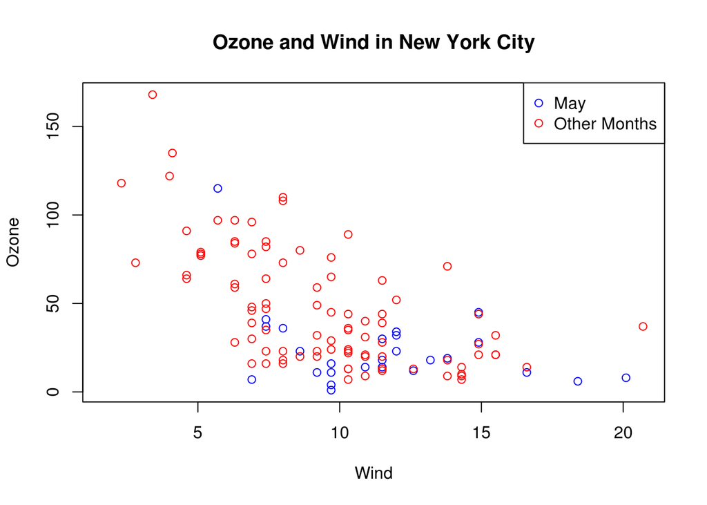

```r
with(airquality,
     plot(Wind, Ozone,
          main='Ozone and Wind in New York City',
          type='n'))  # 'n' for no plotting
with(subset(airquality, Month==5), points(Wind, Ozone, col='blue'))
with(subset(airquality, Month!=5), points(Wind, Ozone, col='red'))
legend('topright', pch=1,
       col=c('blue', 'red'),
       legend=c('May', 'Other Months'))
```

Another example of customerizing `legend`:

```r
legend('topright',
       legend=paste0('Sub_metering_', 1:3),
       col=c("black","red","blue"),
       lty=c(1,1,1),  # the symbols are lines
       bty='n')  # no border around legend
```

Other functions that add to a plot (but do not create a plot):

- `lines`
- `points`
- `text`
- `title`
- `mtext`  
  add arbitrary text to the margines (inner or outer) of the plot
- `axis`

#### Boxplot

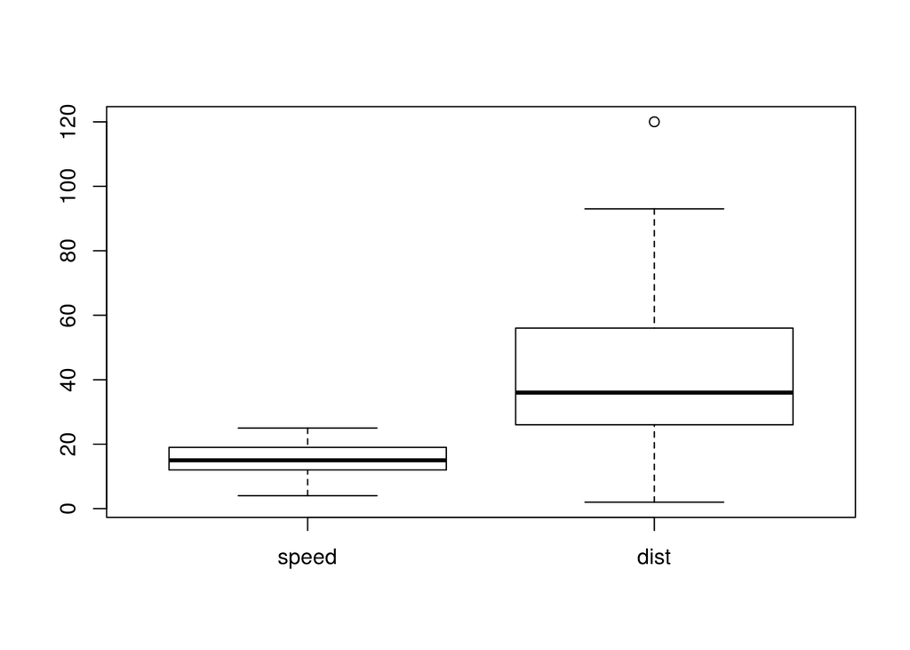

```r
boxplot(cars)
```

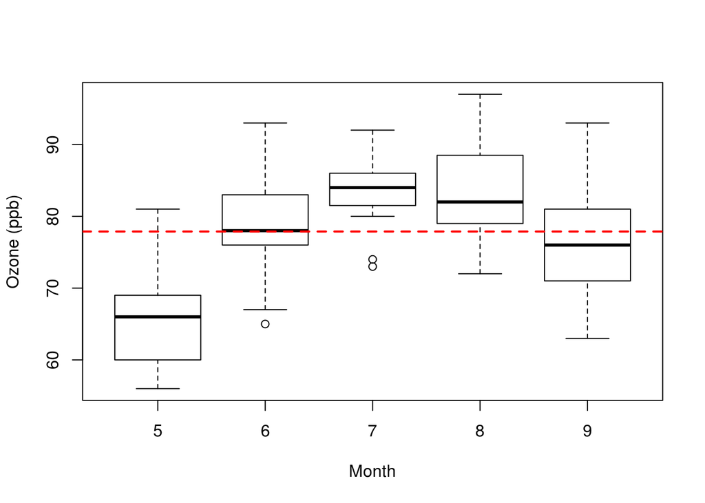

```r
# use formula
boxplot(Temp ~ Month, data = airquality, xlab = 'Month', ylab = 'Ozone (ppb)')
# add horizontal line
abline(h=mean(airquality$Temp, na.rm = TRUE), lwd=2, col='red', lty=2)
```

#### Histogram

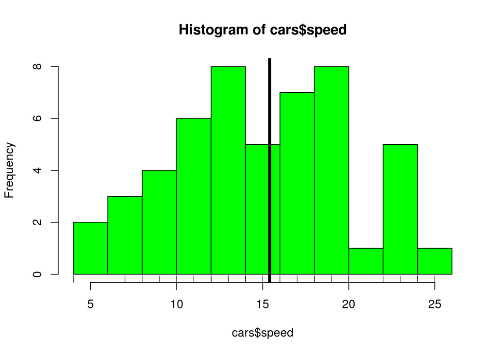

```r
hist(cars$speed, col='green', breaks=10)
rug(cars$speed)
# add vertical line
abline(v=mean(cars$speed, na.rm=TRUE), lwd=4)
```

#### Barplot

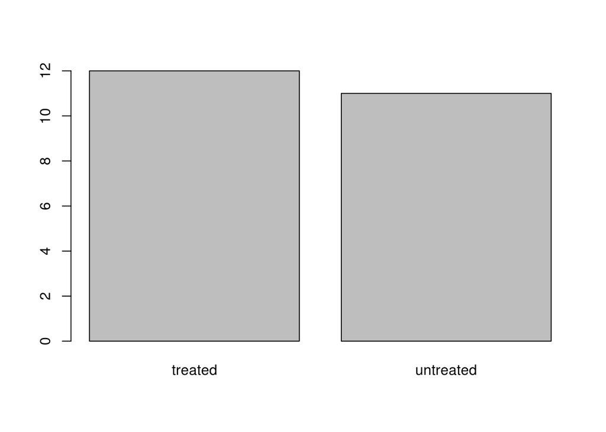

```r
barplot(table(Puromycin$state))
```

#### Create subplots:

```r
par(mfcol=c(1,2))
```

#### Use `with` to simplify code:

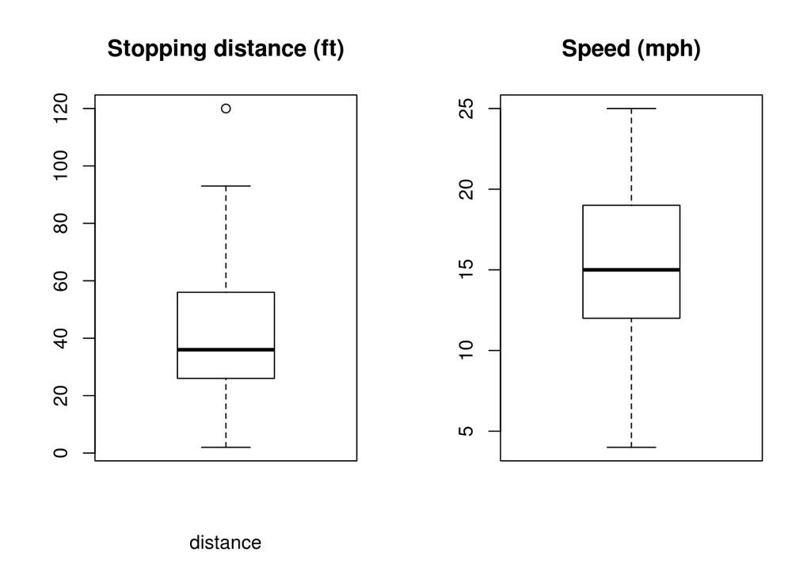

```r
with(cars, {
  boxplot(dist, xlab='distance')
  title('Stopping distance (ft)')
  boxplot(speed)
  title('Speed (mph)')
}
     )
```

[Return to Table of Content]

### lattice

```r
library(lattice)
state <- data.frame(state.x77, region=state.region)
head(state)
```

|  | Population | Income | Illiteracy | Life.Exp | Murder | HS.Grad | Frost | Area | region |
| --- | --- | --- | --- | --- | --- | --- | --- | --- | --- |
| Alabama | 3615 | 3624 | 2.1 | 69.05 | 15.1 | 41.3 | 20 | 50708 | South |
| Alaska | 365 | 6315 | 1.5 | 69.31 | 11.3 | 66.7 | 152 | 566432 | West |
| Arizona | 2212 | 4530 | 1.8 | 70.55 | 7.8 | 58.1 | 15 | 113417 | West |
| Arkansas | 2110 | 3378 | 1.9 | 70.66 | 10.1 | 39.9 | 65 | 51945 | South |
| California | 21198 | 5114 | 1.1 | 71.71 | 10.3 | 62.6 | 20 | 156361 | West |
| Colorado | 2541 | 4884 | 0.7 | 72.06 | 6.8 | 63.9 | 166 | 103766 | West |

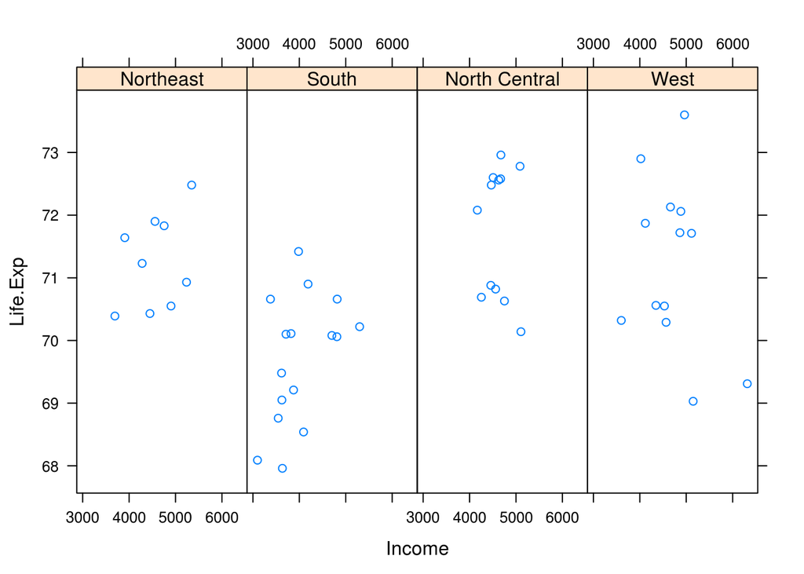

```r
xyplot(Life.Exp ~ Income | region, data=state, layout=c(4,1))
```

Also: `bwplot`

[Return to Table of Content]

### ggplot2

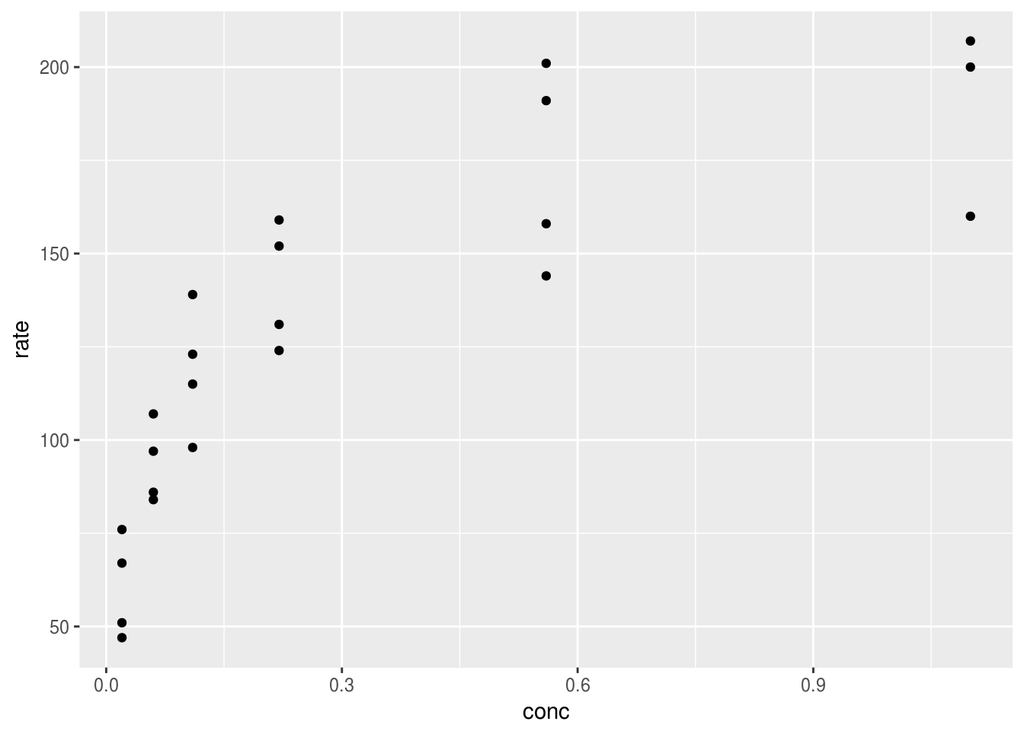

```r
library(ggplot2)
qplot(conc, rate, data=Puromycin)
```

[Return to Table of Content]

### Graphics Devices

Use `?Devices` to see the graphics devices available on current system.

```r
# open file dvice; create pdf file in wd
pdf(file='myplot.pdf')
# create plot
plot(x, y)
# add annotation
title(main='Title')
# close the pdf file device
dev.off()
# now the pdf file can be viewed on computer
```

Find the currently active graphics device:

```r
dev.cur()
```

Change the active graphics device:

```r
dev.set(<integer>)
```

Copy plots:

```r
# copy a plot from one device to another
dev.copy(png, file='myplot.png')
# close the png device
dev.off()

# copy a plot to a pdf file
dev.copy2pdf()
```

[Return to Table of Content]